# Prosper Loan Data Exploration

## Investigation Overview

> **In this investigation**, I wanted to look at the factors that affect a loan’s outcome status and what affects the borrower’s interest rate?

## Dataset Overview

> **Prosper** is America’s first peer-to-peer lending marketplace, with more than 2 million members and over $2,000,000,000 in funded loans. Here we use the data available to the public (last updated on March 11th, 2014) from Prosper, which contains all the listings and loans ever created with 81 variables on each loan/listing, to do some data analysis.

### What is the most income range?

> The income range of the borrower at the time the listing was created.

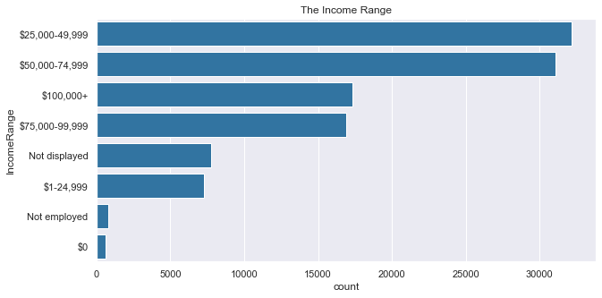

> **We can see that the highest income range for borrowers is 25,000-49,999.**
- **I think that the unemployed people or with 0$ income can take a loan guarantee of things other than income.**

### What is the top borrowers states ?

> The two letter abbreviation of the state of the address of the borrower at the time the Listing was created.

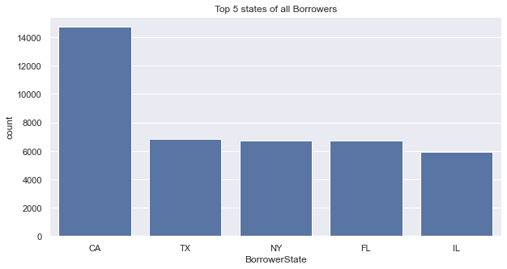

### What is the borrower current emoplyment status?

> The employment status of the borrower at the time they posted the listing.

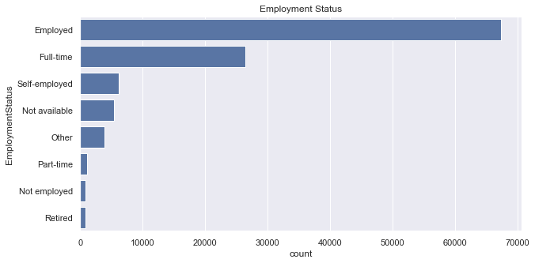

> **We can see that the most frequent employment status is Employed, Full-time, Self-employed.**

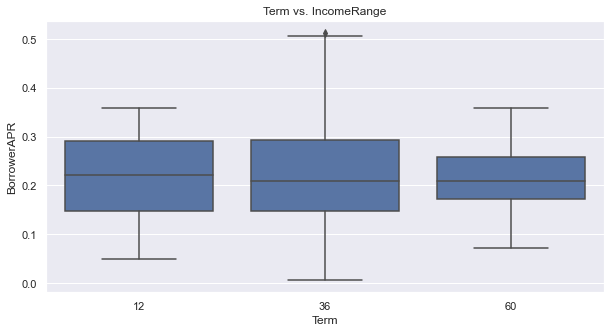

> **We can see that 36 month is the largrest range.**

### BorrowerRate pattern over the years.

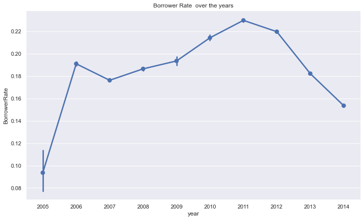

> **We can see here that the BorrowRate increased alot between 2005-2006 and then dropped between 2006-2007 and then increased over the years 2007-2011 and 2011 was at his heighest and then started to drop again over the years 2011-2014**.

### Relationship between IncomeRange & BorrowRate.

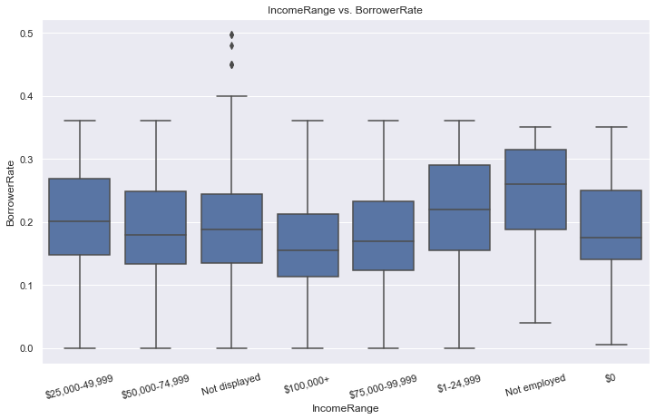

> **We can see that Borrower Rate was highest for not employed, and lowest for who earn more than 100k.**